# COMPSCIX 415.2 Homework 2

Question 3.3.1-1: The code doees not produce the intended coloring of the data point to blue. The reason why the points are not blue is because the “color=”blue" code inside the aes function produces legend information. The “color=”blue" code needs to be outside of the aes function

Question 3.3.1-3(part 1): Mapping a continuous variable to color creates no error.

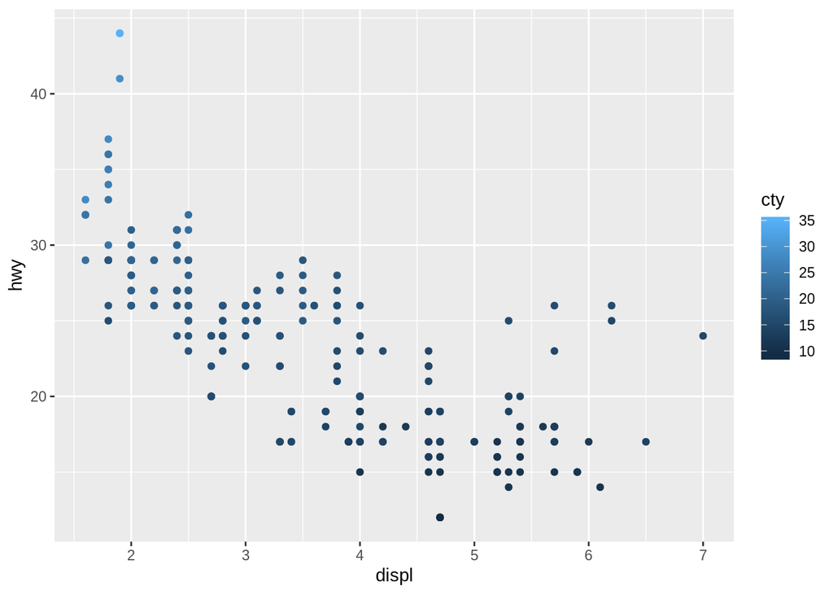

```r
ggplot (data = mpg)+
  geom_point(mapping = aes(x=displ, y=hwy, color=cty))
```

Question 3.3.1-3(part 2): Mapping a continuous variable to size creates no error.

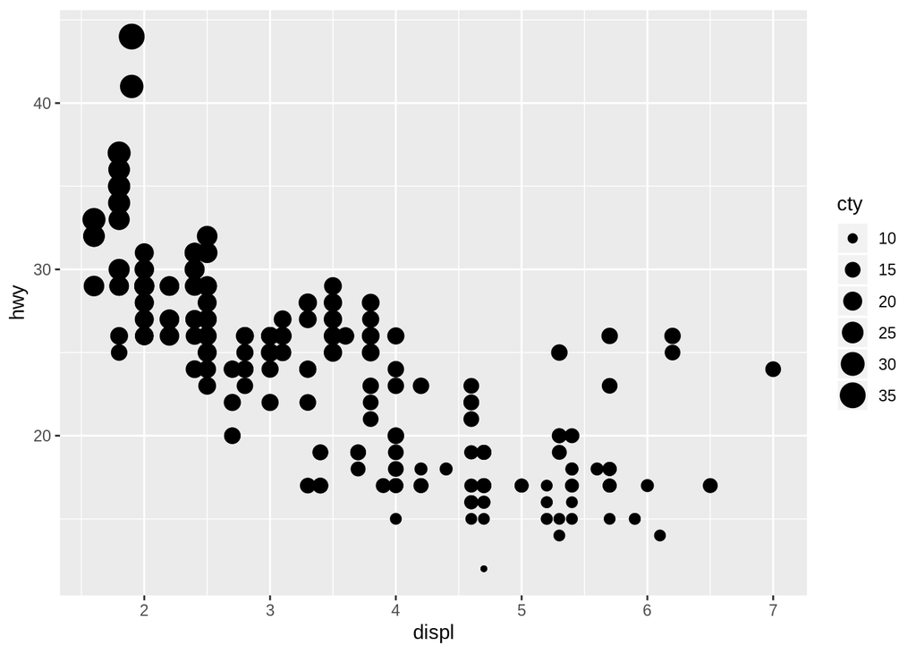

```r
ggplot (data = mpg)+
  geom_point(mapping = aes(x=displ, y=hwy, size=cty))
```

Question 3.3.1-3(part 3): Mapping a continuous variable shape creates an error. Some aesthetics only work on continuous variables while other aesthetics only work on categorical.

# Question 3.3.1-4: Mapping the same variable to multiple aestetics creates a gradient visualization.

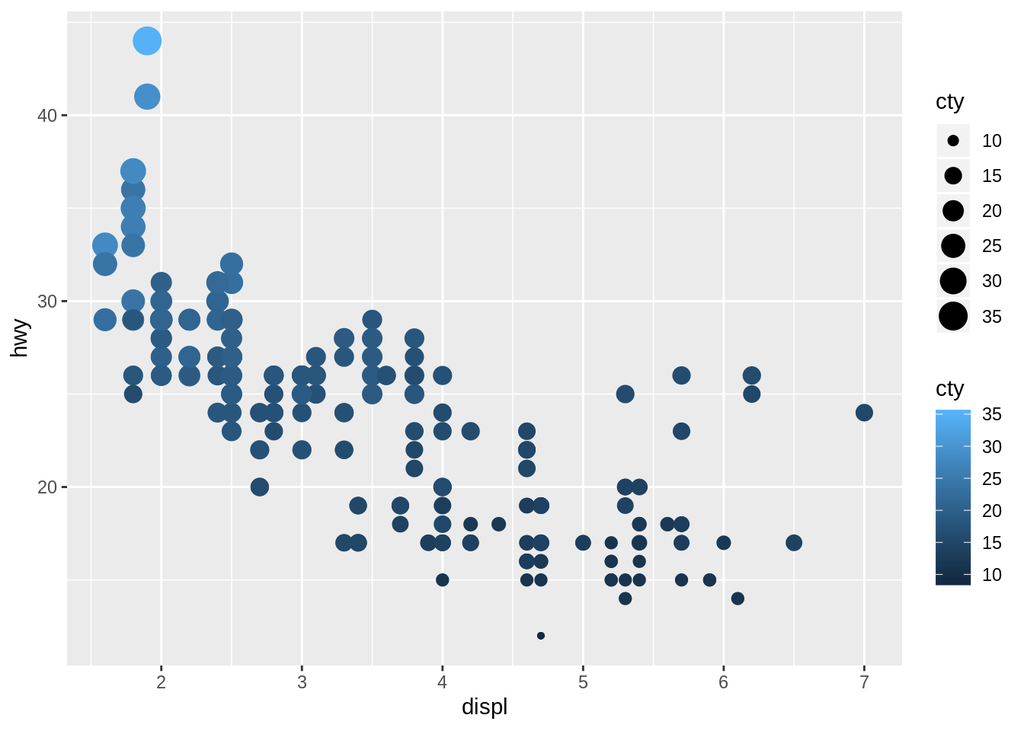

```r
ggplot (data = mpg)+
  geom_point(mapping = aes(x=displ, y=hwy, color=cty, size=cty))
```

Question 3.3.1-5: Stroke aesthetic modifies the width of the border for shapes that have border. The command below generates that information.

```r
?geom_point
```

Question 3.3.1-6: The command create two groups. One group with the criteria that displ is less than 5 and have a distinct color and is also assigned the True boolean. The other group with displ greater than 5 having a distinct color and is assigned the False boolean.

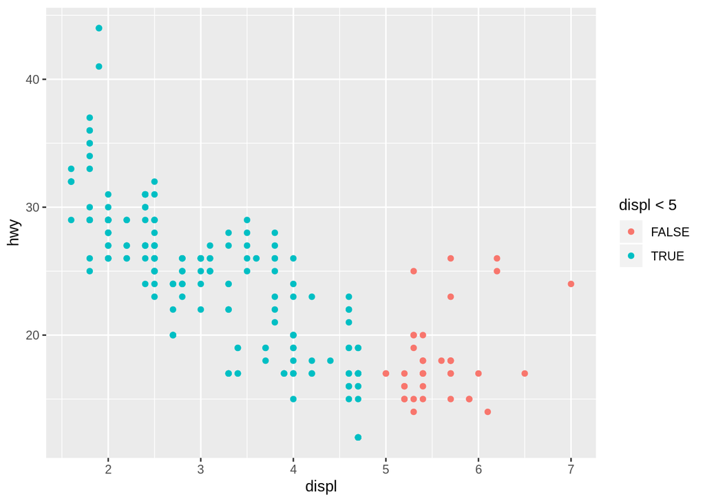

```r
ggplot (data = mpg)+
  geom_point(mapping = aes(x=displ, y=hwy, colour=displ<5))
```

———————————–3.5.1 Exercise—————————————-

Question 3.5.1-4: The advantages is that the subplots has better visualization. The disadvantages is that it is harder to visualize the overall relationship among the facets. For larger dataset, the dataset points overlaps.

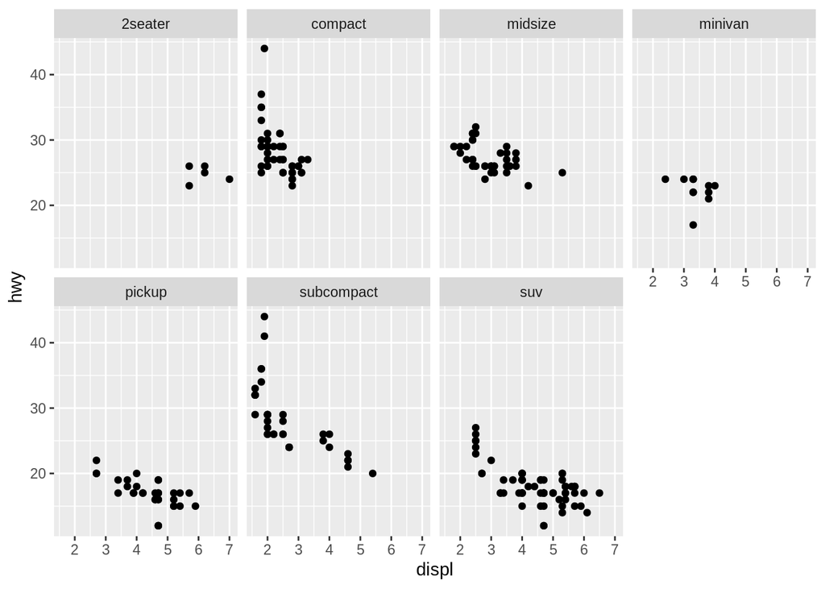

```r
ggplot (data = mpg)+
  geom_point(mapping = aes(x=displ, y=hwy))+
    facet_wrap(~ class, nrow=2)
```

# Question 3.5.1-5: Nrow determines how many rows the faceted plot will have. ncol determines how many columns the faceted plot will have. as.table determines the starting facet to begin filling the plot. dir determines the starting direction fo the filling in the plot. face_grid() does not have nrow and ncol because it deals with discrete variables.

```r
?facet_wrap
?facet_grid
```

——————————–3.6.1 Exercise——————————————-

Question 3.6.1-1: To draw a line chart I would use geom_line(). To draw boxplot I would use geom_boxplot(). To draw a histogram I would use geom_histogram(). To draw an area chart I would use geom_area().

Question 3.6.1-2: The plot would show the data points grouped in color by drv. For each drv group, there would be fit line with the same color as the data points.

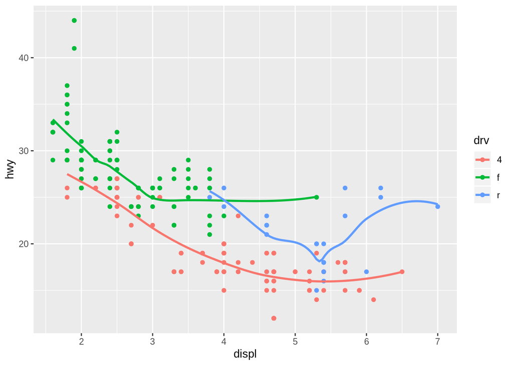

```r
ggplot(data = mpg, mapping = aes(x = displ, y = hwy, color = drv)) +
  geom_point() +
  geom_smooth(se = FALSE)
```

Question 3.6.1-3: The show.legend=FALSE removes the legend. The key would be removed from the graph.

Question 3.6.1-4:se arguement determines whether or not to draw a confidence interval around the smoothing line.

Question 3.6.1-5: There is no difference because they use the same data and mapping settings.

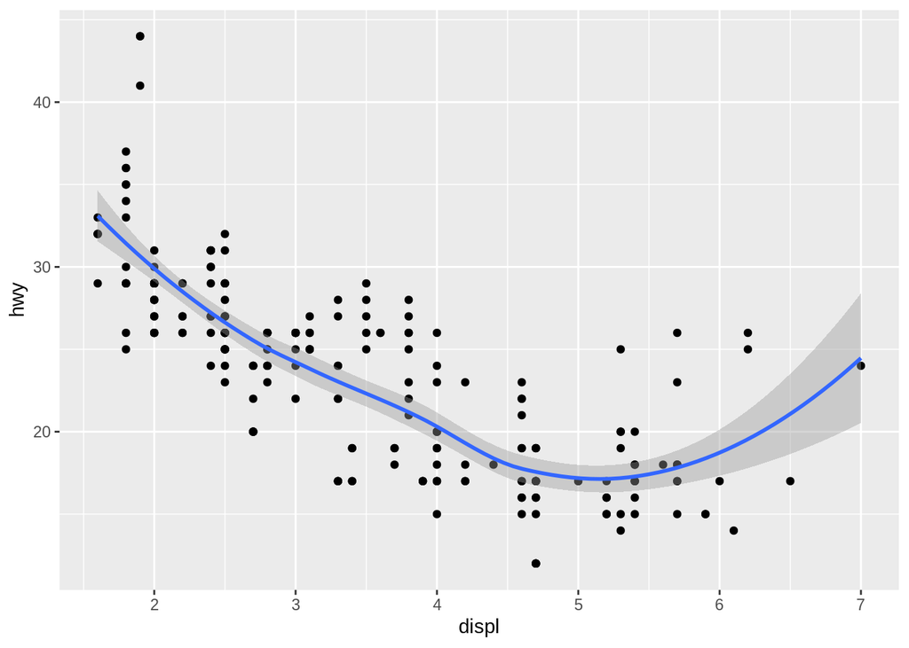

```r
ggplot(data = mpg, mapping = aes(x = displ, y = hwy)) +
  geom_point() +
  geom_smooth()
```

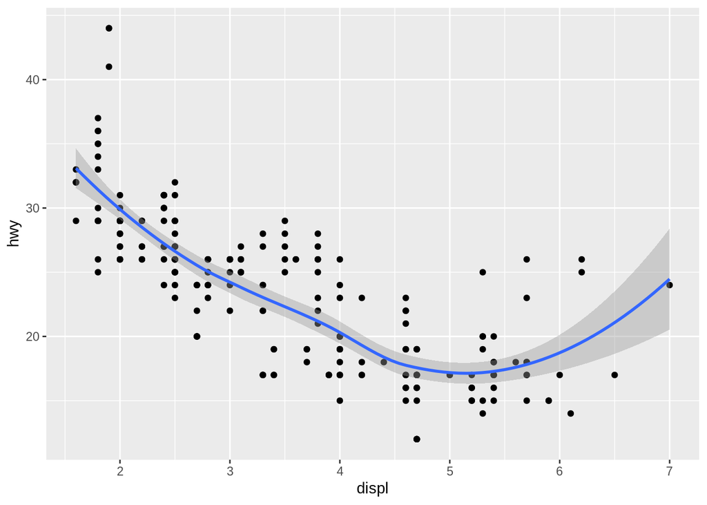

```r
ggplot()+
  geom_point(data=mpg, mapping = aes(x = displ, y = hwy)) +
  geom_smooth(data=mpg, mapping = aes(x = displ, y = hwy))
```

Question 3.6.1-6:

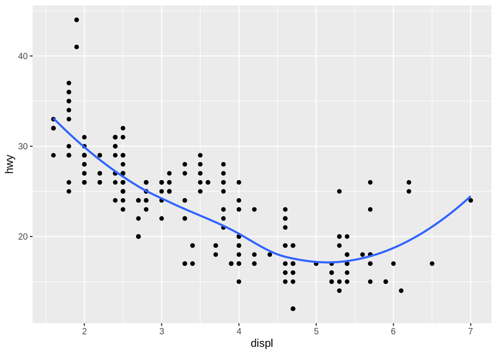

```r
ggplot(data = mpg, mapping = aes(x = displ, y = hwy)) +
  geom_point() +
  geom_smooth(se=FALSE)
```

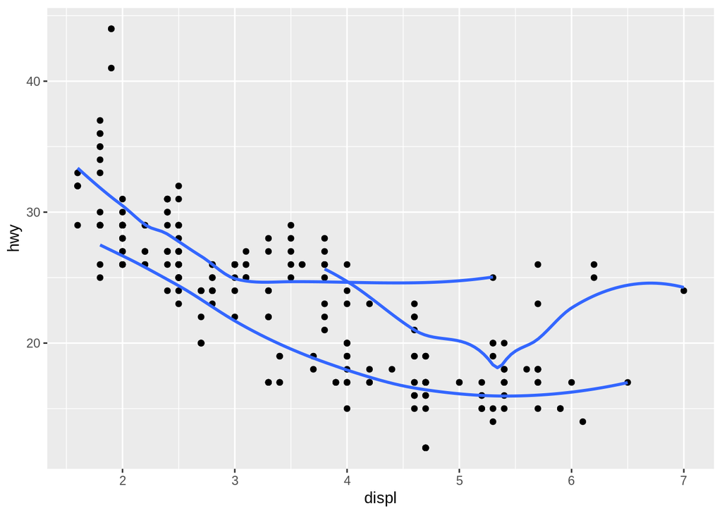

```r
ggplot(data = mpg, mapping = aes(x = displ, y = hwy)) +
  geom_point()+
  geom_smooth(aes(group = drv), se = FALSE)
```

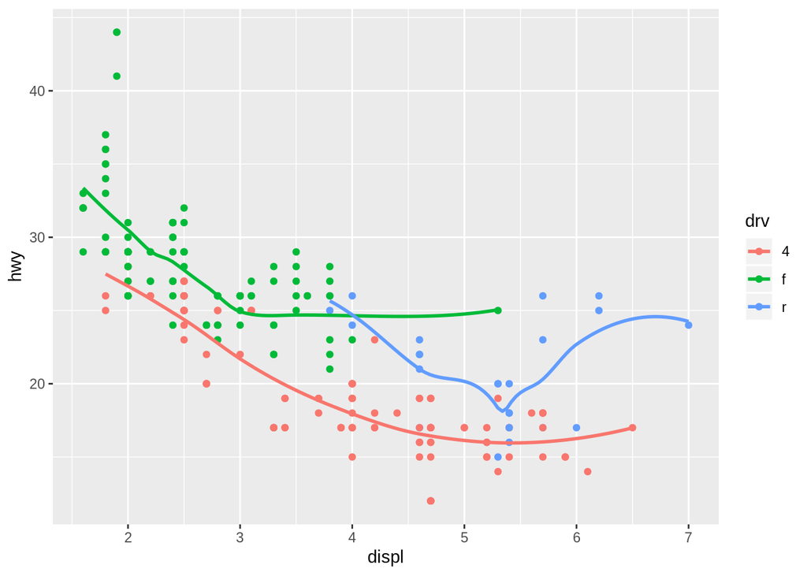

```r
ggplot(data = mpg, mapping = aes(x = displ, y = hwy, color = drv)) +
  geom_point() +
  geom_smooth(se = FALSE)
```

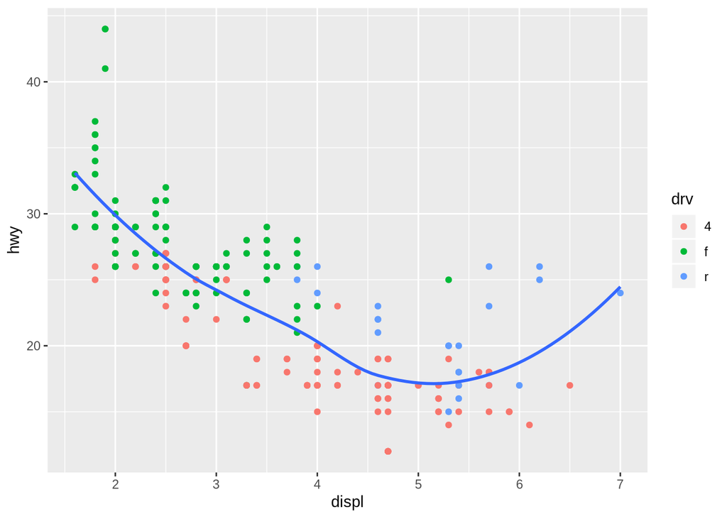

```r
ggplot(data = mpg, mapping = aes(x = displ, y = hwy)) +
  geom_point(aes(color = drv)) +
  geom_smooth(se = FALSE)
```

—————————————–3.7.1 Exercise——————————————–

Question 3.7.1-2: geom_col() leaves the data as it is and you can plot the values of x variable against any y variable. geom_bar() creates two variables (count and prop) and then graphs the count data on the y axis.

—————————————-Graphics Analysis——————————————

I like the large graphics and fonts - easy to read. I like it that the color pallettes used are not wildly distributed.

I don’t like the circular plots. Especially, the largest circle with only a number at the center seems to show a waste of space.